# Monte Carlo Error

# Introdution

We can begin by thinking of this with a specific scenario, say a 10 sided die numbered 1 to 10. The actual probability of rolling a 1 is .1,, yet in practice, it is possible to roll it 10 times and not have a ‘1’ be an outcome, this is the estimated probability. The estimated probability is represented by p-hat, and the actual probability is represented by p. The absolute error is the difference between the estimated probability and actual probability, while the relative error is the absolute error divided by the actual probability. The concept behind the absolute error is that it will decrease as the number of simulations increase- the more times you throw a die, the closer the estimated error will be to the actual error.

# Methods

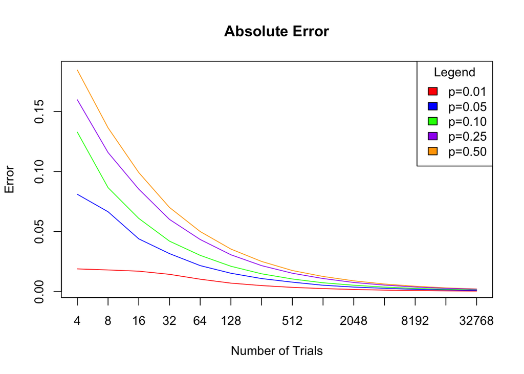

```r
n=2^c(2:15)
p=c(0.01,0.05,0.1,0.25,0.5)
R=5000
abs.err = matrix(NA, nrow=length(p), ncol=length(n))
rel.err = matrix(NA, nrow=length(p), ncol=length(n))
for(i in 1:length(n)){
  for(j in 1:length(p)){
    phat = rbinom(R, n[i], p[j])/n[i]
    abs.err[j,i] = mean(abs(phat-p[j]))
    rel.err[j,i] = mean(abs(phat-p[j])/p[j])
  }
}
plot(x=log(n), y= abs.err[5,], xaxt='n', type="l", col="orange", main="Absolute Error", xlab = "Number of Trials", ylab = "Error")
axis(1, at= log(n),labels=n)
lines(x=log(n), y= abs.err[4,], col="purple")
lines(x=log(n), y= abs.err[3,], col="green")
lines(x=log(n), y= abs.err[2,], col="blue")
lines(x=log(n), y= abs.err[1,], col="red")
legend("topright", legend=c("p=0.01", "p=0.05", "p=0.10","p=0.25","p=0.50"), fill =c("red", "blue","green","purple","orange"), title="Legend", text.font=1)
```

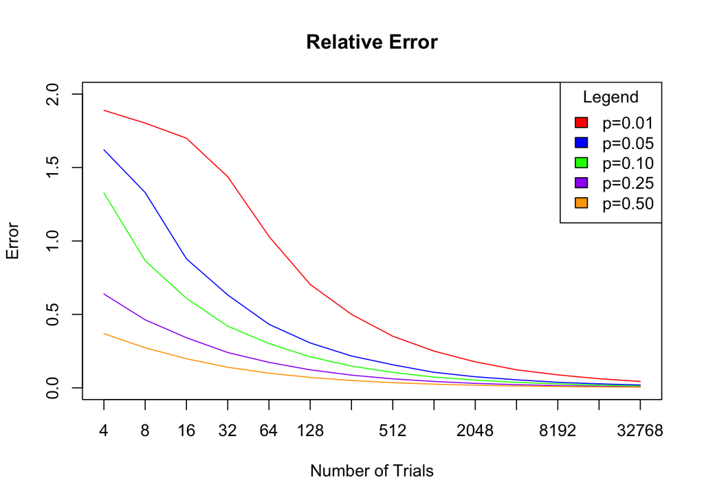

```r
plot(x=log(n), y= rel.err[1,], xaxt='n', type="l", col="red", ylim=c(0,2), main="Relative Error", xlab = "Number of Trials", ylab = "Error")
axis(1, at= log(n),labels=n)
lines(x=log(n), y= rel.err[4,], col="purple")
lines(x=log(n), y= rel.err[3,], col="green")
lines(x=log(n), y= rel.err[2,], col="blue")
lines(x=log(n), y= rel.err[5,], col="orange")
legend("topright", legend=c("p=0.01", "p=0.05", "p=0.10","p=0.25","p=0.50"), fill =c("red", "blue","green","purple","orange"), title="Legend", text.font=1)
```

# Interpertation

Estimated probability = p-hat Actual probability = p

Absolute error = p-hat - p,  
Relative error = absolute error/p

We see the absolute error decrease as the number of simulations increase- the more times you throw a die, the closer the estimated error will be to the actual error. And similarly, the relative error decrease as the number of simulations increase.